# Loading Data

Author

Affiliation

Griffen Wakelin

[Dalhousie University](https://www.dal.ca)

Published

February 6, 2024

Modified

February 6, 2024

# The `anndata` object

Single-cell datasets in `scanpy` are formatted according to the annotated data (`anndata`) python package. Interested readers can view more complete introductions to the `anndata` object given in the [`scverse`’s “Getting started with the `anndata` package”](https://scverse-tutorials.readthedocs.io/en/latest/notebooks/anndata_getting_started.html) and [`anndata`’s “Getting started with anndata”](https://anndata.readthedocs.io/en/latest/tutorials/notebooks/getting-started.html) tutorials.

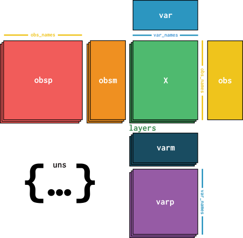

anndata-format

## The active matrix (`adata.X`)

```python
import anndata as ad
import numpy as np
import scanpy as sc

x = np.random.poisson(lam = 1.0, size = (100, 100))
print(x)
```

```
[[1 1 3 ... 1 1 1]
 [0 2 3 ... 0 1 2]
 [2 2 0 ... 1 0 1]
 ...
 [0 1 2 ... 0 1 0]
 [0 3 1 ... 0 0 0]
 [2 1 1 ... 0 0 3]]
```

We can create an `anndata` object from this array alone:

```python
adata = ad.AnnData(X = x)
print(adata)
```

```
AnnData object with n_obs × n_vars = 100 × 100
```

Our original array is accessible using the `.X` method of the `anndata` object:

```python
adata.X
```

```
array([[1, 1, 3, ..., 1, 1, 1],
       [0, 2, 3, ..., 0, 1, 2],
       [2, 2, 0, ..., 1, 0, 1],
       ...,
       [0, 1, 2, ..., 0, 1, 0],
       [0, 3, 1, ..., 0, 0, 0],
       [2, 1, 1, ..., 0, 0, 3]])
```

## Cell- (`adata.obs`) and gene-level (`adata.var`) metadata

`anndata` objects are arranged in such a way that they can store (and save) cell- and gene-level metadata very easily. Cell-level metadata are stored in a `pandas` DataFrame accessible using the `.obs` method (obs for observations a.k.a. cells) and the gene-level metadata in a `pandas` DataFrame accessible via the `.var` method (for variables a.k.a. genes).

```python
print(adata.obs, adata.var)
```

```
Empty DataFrame
Columns: []
Index: [0, 1, 2, 3, 4, 5, 6, 7, 8, 9, 10, 11, 12, 13, 14, 15, 16, 17, 18, 19, 20, 21, 22, 23, 24, 25, 26, 27, 28, 29, 30, 31, 32, 33, 34, 35, 36, 37, 38, 39, 40, 41, 42, 43, 44, 45, 46, 47, 48, 49, 50, 51, 52, 53, 54, 55, 56, 57, 58, 59, 60, 61, 62, 63, 64, 65, 66, 67, 68, 69, 70, 71, 72, 73, 74, 75…

[100 rows x 0 columns] Empty DataFrame
Columns: []
Index: [0, 1, 2, 3, 4, 5, 6, 7, 8, 9, 10, 11, 12, 13, 14, 15, 16, 17, 18, 19, 20, 21, 22, 23, 24, 25, 26, 27, 28, 29, 30, 31, 32, 33, 34, 35, 36, 37, 38, 39, 40, 41, 42, 43, 44, 45, 46, 47, 48, 49, 50, 51, 52, 53, 54, 55, 56, 57, 58, 59, 60, 61, 62, 63, 64, 65, 66, 67, 68, 69, 70, 71, 72, 73, 74, 75…

[100 rows x 0 columns]
```

In the case where you are importing single-cell datasets, these data frames would be indexed by the cell barcode and gene names, respectively, looking something like this:

```python
adata.obs_names = [f'Cell_{i}' for i in range(adata.n_obs)]
adata.var_names = [f'Gene_{i}' for i in range(adata.n_vars)]
print(adata.obs, adata.var)
```

```
Empty DataFrame
Columns: []
Index: [Cell_0, Cell_1, Cell_2, Cell_3, Cell_4, Cell_5, Cell_6, Cell_7, Cell_8, Cell_9, Cell_10, Cell_11, Cell_12, Cell_13, Cell_14, Cell_15, Cell_16, Cell_17, Cell_18, Cell_19, Cell_20, Cell_21, Cell_22, Cell_23, Cell_24, Cell_25, Cell_26, Cell_27, Cell_28, Cell_29, Cell_30, Cell_31, Cell_32, Cell_…

[100 rows x 0 columns] Empty DataFrame
Columns: []
Index: [Gene_0, Gene_1, Gene_2, Gene_3, Gene_4, Gene_5, Gene_6, Gene_7, Gene_8, Gene_9, Gene_10, Gene_11, Gene_12, Gene_13, Gene_14, Gene_15, Gene_16, Gene_17, Gene_18, Gene_19, Gene_20, Gene_21, Gene_22, Gene_23, Gene_24, Gene_25, Gene_26, Gene_27, Gene_28, Gene_29, Gene_30, Gene_31, Gene_32, Gene_…

[100 rows x 0 columns]
```

## Additional metadata slots (`adata.uns`, `adata.obsm`, `adata.varm`, `adata.obsp`)

As you perform a normal single-cell workflow, different slots of the anndata object will gradually be populated:

```python
# Quality Control
sc.pp.calculate_qc_metrics(adata, percent_top=None, log1p=False, inplace=True)
print(adata)
```

```
AnnData object with n_obs × n_vars = 100 × 100
    obs: 'n_genes_by_counts', 'total_counts'
    var: 'n_cells_by_counts', 'mean_counts', 'pct_dropout_by_counts', 'total_counts'
```

```python
# PCA
sc.pp.pca(adata)
print(adata)
```

```
AnnData object with n_obs × n_vars = 100 × 100
    obs: 'n_genes_by_counts', 'total_counts'
    var: 'n_cells_by_counts', 'mean_counts', 'pct_dropout_by_counts', 'total_counts'
    uns: 'pca'
    obsm: 'X_pca'
    varm: 'PCs'
```

```python
# Neighbors graph construction + Clustering
sc.pp.neighbors(adata)
sc.tl.leiden(adata)
print(adata)
```

```
AnnData object with n_obs × n_vars = 100 × 100
    obs: 'n_genes_by_counts', 'total_counts', 'leiden'
    var: 'n_cells_by_counts', 'mean_counts', 'pct_dropout_by_counts', 'total_counts'
    uns: 'pca', 'neighbors', 'leiden'
    obsm: 'X_pca'
    varm: 'PCs'
    obsp: 'distances', 'connectivities'
```

We can view various slots of the `anndata` object to see which metadata it is holding:

```python
adata.obs
```

|  | n_genes_by_counts | total_counts | leiden |
| --- | --- | --- | --- |
| Cell_0 | 60 | 88 | 2 |
| Cell_1 | 64 | 99 | 0 |
| Cell_2 | 65 | 102 | 5 |
| Cell_3 | 52 | 79 | 4 |
| Cell_4 | 72 | 111 | 1 |
| ... | ... | ... | ... |
| Cell_95 | 59 | 113 | 5 |
| Cell_96 | 64 | 110 | 6 |
| Cell_97 | 60 | 106 | 2 |
| Cell_98 | 60 | 85 | 3 |
| Cell_99 | 63 | 101 | 0 |

100 rows × 3 columns

```python
adata.var
```

|  | n_cells_by_counts | mean_counts | pct_dropout_by_counts | total_counts |
| --- | --- | --- | --- | --- |
| Gene_0 | 60 | 0.88 | 40.0 | 88 |
| Gene_1 | 60 | 1.04 | 40.0 | 104 |
| Gene_2 | 59 | 0.92 | 41.0 | 92 |
| Gene_3 | 63 | 1.01 | 37.0 | 101 |
| Gene_4 | 60 | 1.00 | 40.0 | 100 |
| ... | ... | ... | ... | ... |
| Gene_95 | 70 | 1.20 | 30.0 | 120 |
| Gene_96 | 62 | 0.91 | 38.0 | 91 |
| Gene_97 | 63 | 0.98 | 37.0 | 98 |
| Gene_98 | 59 | 0.85 | 41.0 | 85 |
| Gene_99 | 66 | 0.94 | 34.0 | 94 |

100 rows × 4 columns

# Loading in data

The goal of loading in data is to have the `anndata` object formatted as previously described, with the counts matrix in the `.X` slot, the cell barcode names in the `.obs_names` slot, and the gene names in the `.var_names` slot.

## 10x Genomics Data

In the case where you have a 10x Genomics dataset in the Matrix Market format, `scanpy` provides a convenience function which will organize the data automatically:

```python
!ls outs/filtered_feature_bc_matrix/
```

```
barcodes.tsv.gz features.tsv.gz matrix.mtx.gz
```

```python
import scanpy as sc

adata = sc.read_10x_mtx("outs/filtered_feature_bc_matrix/")
print(adata)
```

```
AnnData object with n_obs × n_vars = 7489 × 32285
    var: 'gene_ids', 'feature_types'
```

This is also true for 10x datasets in the H5 format:

```python
adata = sc.read_10x_h5("outs/filtered_feature_bc_matrix.h5")
print(adata)
```

```
AnnData object with n_obs × n_vars = 7489 × 32285
    var: 'gene_ids', 'feature_types', 'genome'
```

See 10x Genomics’ [support page on cellranger outputs](https://www.10xgenomics.com/support/software/cell-ranger/latest/analysis/outputs/cr-outputs-overview) for more details on how their output files are organized.

## Tabular data

Datasets from platforms besides 10x do not have an agreed-upon format but tend to be tabular in nature (in the form of .csv or .tsv files). In these cases, you need to do the data wrangling yourself.

As an example (from GSE129114), here is a dataset generated using the smart-seq2 protocol. I will first load in the data using a naive, default approach with `pandas.read_csv()`:

```python
import pandas as pd
df = pd.read_csv("GSE129114_E9.5_anterior_Sox10_counts.txt")
df
```

|  | SS2_17_554_A21 SS2_17_554_A20 SS2_17_554_A9 SS2_17_554_A19 SS2_17_554_A24 SS2_17_554_A22 SS2_17_554_A11 SS2_17_554_A23 SS2_17_554_A14 SS2_17_554_A17 SS2_17_554_A16 SS2_17_554_A15 SS2_17_554_A13 SS2_17… |
| --- | --- |
| 0 | Adora1 0 0 0 0 0 0 0 0 0 0 0 0 0 0 0 0 7 0 0 0... |
| 1 | Sntg1 0 1 0 0 0 0 0 0 0 0 0 11 0 0 0 0 0 0 0 0... |
| 2 | Prim2 2 15 7 22 0 24 9 7 71 7 27 74 4 14 4 0 3... |
| 3 | Bai3 0 0 0 0 0 0 0 0 0 0 0 0 0 0 0 0 0 0 0 0 0... |
| 4 | Cflar 0 0 0 0 0 0 0 1 4 0 0 0 0 2 3 0 7 1 3 0 ... |
| ... | ... |
| 23714 | Tmlhe 0 0 0 0 0 0 0 0 0 0 0 0 0 0 0 0 0 0 0 0 ... |
| 23715 | Vamp7 0 0 0 0 0 0 0 0 0 0 0 0 0 0 0 0 0 0 0 0 ... |
| 23716 | Spry3 0 0 0 0 0 0 0 0 0 0 0 0 0 0 0 0 0 0 0 0 ... |
| 23717 | Zf12 0 0 0 0 0 0 0 0 0 0 0 0 0 0 0 0 0 0 0 0 0... |
| 23718 | eGFP 0 0 0 0 0 0 0 0 0 0 0 0 0 0 0 0 0 0 0 0 0... |

23719 rows × 1 columns

Using only a few modifications to our `pandas.read_csv()` function, we can rearrange our data such that it can be made into a `anndata` object:

```python
df = pd.read_csv("GSE129114_E9.5_anterior_Sox10_counts.txt", delimiter=" ", header=0, index_col=0)
df
```

|  | SS2_17_554_A21 | SS2_17_554_A20 | SS2_17_554_A9 | SS2_17_554_A19 | SS2_17_554_A24 | SS2_17_554_A22 | SS2_17_554_A11 | SS2_17_554_A23 | SS2_17_554_A14 | SS2_17_554_A17 | ... | SS2_18_110_P14 | SS2_18_110_P18 | SS2_18_110_P17 | SS2_18_110_P22 | SS2_18_110_P24 | SS2_18_110_P23 | SS2_18_110_P13 | SS2_18_110_P16 | SS2_18_110_P20 | SS2_18_110_P19 |
| --- | --- | --- | --- | --- | --- | --- | --- | --- | --- | --- | --- | --- | --- | --- | --- | --- | --- | --- | --- | --- | --- |
| Adora1 | 0 | 0 | 0 | 0 | 0 | 0 | 0 | 0 | 0 | 0 | ... | 21 | 0 | 0 | 0 | 0 | 0 | 0 | 0 | 0 | 0 |
| Sntg1 | 0 | 1 | 0 | 0 | 0 | 0 | 0 | 0 | 0 | 0 | ... | 0 | 0 | 0 | 0 | 0 | 0 | 0 | 0 | 0 | 0 |
| Prim2 | 2 | 15 | 7 | 22 | 0 | 24 | 9 | 7 | 71 | 7 | ... | 0 | 12 | 25 | 0 | 0 | 0 | 39 | 44 | 27 | 9 |
| Bai3 | 0 | 0 | 0 | 0 | 0 | 0 | 0 | 0 | 0 | 0 | ... | 0 | 0 | 0 | 0 | 0 | 0 | 0 | 0 | 0 | 0 |
| Cflar | 0 | 0 | 0 | 0 | 0 | 0 | 0 | 1 | 4 | 0 | ... | 8 | 0 | 0 | 0 | 0 | 0 | 0 | 0 | 0 | 0 |
| ... | ... | ... | ... | ... | ... | ... | ... | ... | ... | ... | ... | ... | ... | ... | ... | ... | ... | ... | ... | ... | ... |
| Tmlhe | 0 | 0 | 0 | 0 | 0 | 0 | 0 | 0 | 0 | 0 | ... | 0 | 0 | 0 | 0 | 0 | 0 | 0 | 0 | 0 | 0 |
| Vamp7 | 0 | 0 | 0 | 0 | 0 | 0 | 0 | 0 | 0 | 0 | ... | 0 | 0 | 0 | 0 | 0 | 0 | 0 | 0 | 0 | 0 |
| Spry3 | 0 | 0 | 0 | 0 | 0 | 0 | 0 | 0 | 0 | 0 | ... | 0 | 0 | 0 | 0 | 0 | 0 | 0 | 0 | 0 | 0 |
| Zf12 | 0 | 0 | 0 | 0 | 0 | 0 | 0 | 0 | 0 | 0 | ... | 0 | 0 | 0 | 0 | 0 | 0 | 0 | 0 | 0 | 0 |
| eGFP | 0 | 0 | 0 | 0 | 0 | 0 | 0 | 0 | 0 | 0 | ... | 0 | 0 | 0 | 0 | 0 | 0 | 0 | 0 | 0 | 0 |

23719 rows × 524 columns

The final step is to create the `anndata` object:

```python
obs_names = df.columns.values
var_names = df.index.values
x = df.to_numpy().T

adata = ad.AnnData(X = x)
adata.obs_names = obs_names
adata.var_names = var_names

print(adata)
```

```
AnnData object with n_obs × n_vars = 524 × 23719
```

## Data from R

The other common format that you will find single-cell datasets in is formats specific to R (either `SingleCellExperiment` or `Seurat` objects), which tend to be saved in `.RDS` files. This situation is quite a bit more complex than the other two, and I would recommend just consulting someone who has experience converting these into formats into those amenable for analysis in python.